# 第 1 章 符号约定与数据

## 1.1 符号约定

本节给出全书统一采用的数学符号约定。

粗体符号表示向量和矩阵。矩阵用大写字母表示，向量用小写字母表示。$\mathbf{v}'$ 和 $\mathbf{M}'$ 分别表示 $\mathbf{v}$ 和 $\mathbf{M}$ 的转置。$\mathbf{M}=[m]_{i,j}$ 中，$i$ 是行索引，$j$ 是列索引。

全书同时采用两套相互对应的记号。第一套是机器学习记号，其中**标签**（也称**输出**、**因变量**或**目标变量**）$\mathbf{y}=y_i$ 由特征  
$\mathbf{X}_i=(x_{i,1},\dots,x_{i,K})$ 的函数来近似。特征矩阵 $\mathbf{X}$ 的维度为 $I\times K$：共有 $I$ 个**样本**，每个样本对应矩阵的一行；每个样本有 $K$ 个**属性**、**特征**、**输入变量**或**预测变量**，用作**自变量**或**解释变量**（这些术语在全书中互换使用）。有时，为简化记号，我们将第 $i$ 个样本（一行）记为 $\textbf{x}_i$，它对应 $\textbf{X}$ 中的一行；类似地，将一个特征列向量记为 $\textbf{x}_k$，它对应 $\textbf{X}$ 中的一列。

第二套是与第一套直接对应的金融记号。我们经常使用由价格数据计算得到的离散收益率 $r_{t,n}=p_{t,n}/p_{t-1,n}-1$。这里，$t$ 是时间索引，$n$ 是资产索引。除非另作说明，收益率均按一期计算；一期有时为一个月，有时为一年。可能产生歧义时，我们会另行说明收益率的记号。

与上述约定一致，收益率的观测日期数记为 $T$，资产数记为 $N$。资产的特征或属性记为 $x_{t,n}^{(k)}$：它表示公司或资产 $n$ 在时刻 $t$ 的第 $k$ 个属性值。在堆叠记号中，$\mathbf{x}_{t,n}$ 表示资产 $n$ 在时刻 $t$ 的特征向量。此外，$\mathbf{r}_t$ 表示时刻 $t$ 所有资产的收益率，$\mathbf{r}_n$ 表示资产 $n$ 在所有时期的收益率。收益率通常充当因变量，也就是机器学习中的标签。无风险资产的收益率记为 $r_{t,f}$。

大多数情况下，两套记号之间的对应关系如下。第 $i$ 个**样本**对应面板数据中的一条资产—日期**观测** $(t,n)$，即某个特定日期与某家特定公司。如果数据为没有缺失字段的完整矩形，则 $I=T\times N$。标签通常是根据未来某段时期计算的公司表现指标，特征则由公司在时刻 $t$ 的属性构成。因此，用于因子投资的机器学习模型旨在确定一种映射关系，将公司在时刻 $t$ 的特征映射到其未来表现。

对于常用的特殊矩阵，$\mathbf{I}_N$ 表示 $(N\times N)$ 单位矩阵。

沿用概率论中的记号，我们以 $\mathbb{E}[\cdot]$ 表示期望算子，以 $\mathbb{E}_t[\cdot]$ 表示条件期望；相应的滤过 $\mathcal{F}_t$ 表示时刻 $t$ 可获得的全部信息。更准确地说，$\mathbb{E}_t[\cdot]=\mathbb{E}[\cdot | \mathcal{F}_t]$，$\mathbb{V}[\cdot]$ 表示方差算子。根据上下文，概率简记为 $P$，有时也采用较繁复的记号 $\mathbb{P}$。概率密度函数（pdf）用小写字母（$f$）表示，累积分布函数（cdf）用大写字母（$F$）表示。我们将同分布写作 $X \overset{d}{=}Y$；这等价于在变量的支撑集上，对所有 $z$ 都有 $F_X(z)=F_Y(z)$。对于随机过程 $X_t$，如果 $X_t$ 的分布不随时间变化，即 $X_t\overset{d}{=}X_s$，则称其为**平稳**过程，其中 $\overset{d}{=}$ 表示同分布。

渐近行为有时用常见的朗道记号 $o(\cdot)$ 和 $O(\cdot)$ 表示。符号 $∝$ 表示成比例关系：$x∝y$ 表示 $x$ 与 $y$ 成比例。对 $x$ 求导时，采用标准记号 $\frac{\partial}{\partial x}$；计算全部偏导数（即梯度向量）时，则采用紧凑记号 $∇$。

在方程中，等式左端和右端可分别简写为 l.h.s. 和 r.h.s.。

最后列出几个函数：

- $1_{\{x \}}$：条件 $x$ 的指示函数；$x$ 为真时取 1，否则取 0。
- $\phi(\cdot)$ 和 $\Phi(\cdot)$ 分别是标准正态分布的概率密度函数和累积分布函数。
- card $(\cdot)=\#(\cdot)$ 是基数函数的两种记号，用于计算作为函数参数给定的集合所含元素的数量。
- $\lfloor \cdot \rfloor$ 是向下取整函数。
- 对于实数 $x$，$[x]^+$ 是 $x$ 的正部，即 $\max(0,x)$。
- tanh$(\cdot)$ 是双曲正切函数：tanh$(x)=\frac{e^x-e^{-x}}{e^x+e^{-x}}$。
- ReLU$(\cdot)$ 是修正线性单元激活函数：ReLU$(x)=\max(0,x)$。
- s$(\cdot)$ 表示 softmax 函数：s$(\textbf{x})_i=\frac{e^{x_i}}{\sum_{j=1}^Je^{x_j}}$，其中下标 $i$ 指向量的第 $i^{th}$ 个元素。

## 1.2 数据集

为保证**可复现性**，全书都以一个金融数据集为基础，通过实现示例来说明所介绍的概念。该数据集可从 https://github.com/shokru/mlfactor.github.io/tree/master/material 获取，包含 1,207 只在美国上市的股票（公司可能来自加拿大或墨西哥）的信息，时间范围为 1998 年 11 月至 2019 年 3 月。在每个时点，样本中的公司均由 93 个**特征**描述。这些属性涵盖多个方面：

- **估值**（盈利收益率、会计比率）；
- **盈利能力**和质量（净资产收益率）；
- **动量**和技术分析（过去收益率、相对强弱指标）；
- **风险**（波动率）；
- **估计值**（每股收益）；
- **成交量**和**流动性**（股票换手率）。

样本并非严格的矩形面板：数据点没有缺失，但公司数量及其属性均随时间变化。这使回测计算更加棘手，却也更贴近现实。

```python
import pandas as pd                       # Activate the data science package
data_raw=pd.read_csv('data_ml.csv')       # Load the data
idx_date=data_raw.index[(data_raw['date'] > '1999-12-31') & (data_raw['date'] < '2019-01-01')].tolist() # creating and index to retrive the dates
data_ml=data_raw.iloc[idx_date]           # filtering the dataset according to date index
data_ml.iloc[1:6,1:6]
```

|  | date | Advt_12M_Usd | Advt_3M_Usd | Advt_6M_Usd | Asset_Turnover |
| --- | --- | --- | --- | --- | --- |
| 13031 | 2000-01-31 | 0.59 | 0.67 | 0.65 | 0.49 |
| 13032 | 2000-01-31 | 0.74 | 0.75 | 0.76 | 0.68 |
| 13033 | 2000-01-31 | 0.24 | 0.22 | 0.22 | 0.47 |
| 13034 | 2000-01-31 | 0.68 | 0.71 | 0.70 | 0.93 |
| 13035 | 2000-01-31 | 0.29 | 0.29 | 0.31 | 0.26 |

该数据共有 99 列、268336 行。前两列是股票标识符和日期，随后 93 列是特征（详见附录中的表 17.1），最后 4 列是标签。观测频率为月度。现实数据通常如此，资产数量会随时间变化，见图 1.1。

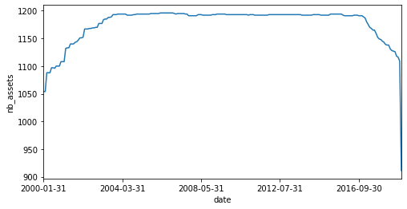

```python
import matplotlib.pyplot as plt
pd.Series(data_ml.groupby('date').size()).plot(figsize=(8,4)) # counting the number of assets for each date
plt.ylabel('nb_assets')                                        # adding the ylabel and plotting
```

图 1.1：各时点的资产数量。

数据集直接给出四个**标签**：R1M_Usd、R3M_Usd、R6M_Usd 和 R12M_Usd，分别对应股票未来 1 个月、3 个月、6 个月和 12 个月的收益率。这些收益率是**总收益率**，即计入相应期间内可能支付的**股息**，因此比单纯的价格收益率更能反映实际投资收益。关于价格收益率与股息相分离所造成的影响，参见 Hartzmark 和 Solomon (2019) 的分析。这些标签位于数据集最后 4 列。下面给出其描述性统计量。

```python
## # A tibble: 4 x 5
##   Label      mean    sd    min   max
##   <chr>     <dbl> <dbl>  <dbl> <dbl>
## 1 R12M_Usd 0.137  0.738 -0.991  96.0
## 2 R1M_Usd  0.0127 0.176 -0.922  30.2
## 3 R3M_Usd  0.0369 0.328 -0.929  39.4
## 4 R6M_Usd  0.0723 0.527 -0.98  107.
```

为后续建模做准备，我们将预测变量的名称存入内存，并另存一份短得多的预测变量列表。

```python
features=list(data_ml.iloc[:,3:95].columns) # Keep the feature's column names (hard-coded, beware!)
features_short =["Div_Yld", "Eps", "Mkt_Cap_12M_Usd", "Mom_11M_Usd",
                    "Ocf", "Pb", "Vol1Y_Usd"]
```

预测变量已经过均匀化处理，即在任意给定时点，任一特征的横截面分布均为均匀分布。由于样本中只有 1,207 只股票，下图的直方图不会呈现为完美的矩形。

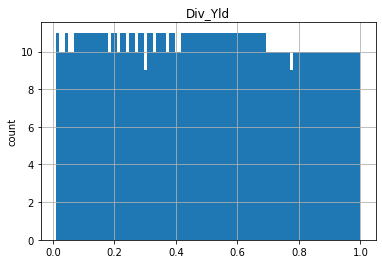

```python
col_feat_Div_Yld=data_ml.columns.get_loc('Div_Yld') # finding the location of the column/feature Div_Yld
is_custom_date =data_ml['date']=='2000-02-29'       # creating a boolean index to filter on
data_ml[is_custom_date].iloc[:,[col_feat_Div_Yld]].hist(bins=100) # using the hist
plt.ylabel('count')
```

图 1.2：2000 年 2 月 29 日的股息率特征分布。

原始标签（未来收益率）是数值型的，用于以预测标量实数为目标的回归练习。有时，任务也可能是预测**类别**（也称**类**），例如“买入”“持有”或“卖出”。为了进行这类分类分析，我们另外创建了类别型标签。

```python
df_median=[]          #creating empty placeholder for temporary dataframe
df=[]                #creating empty placeholder for temporary dataframe
import numpy as np
df_median=data_ml[['date','R1M_Usd','R12M_Usd']].groupby(['date']).median() # computings medians for both labels at each date
df_median.rename(columns={"R1M_Usd": "R1M_Usd_median", "R12M_Usd": "R12M_Usd_median"},inplace=True)
df = pd.merge(data_ml,df_median,how='left', on=['date'])             # join the dataframes
data_ml['R1M_Usd_C'] = np.where(df['R1M_Usd'] > df['R1M_Usd_median'], 1.0, 0.0) # Create the categorical labels
data_ml['R12M_Usd_C'] = np.where(df['R12M_Usd'] > df['R12M_Usd_median'], 1.0, 0.0) # Create the categorical labels
df_median=[]          #removing the temp dataframe to keep it light!
df=[]                 #removing the temp dataframe to keep it light!
```

新标签是二元变量：原始收益率高于相应期限收益率的中位数时取 1（真），否则取 0（假）。因此，在每个时点，一半样本的标签为 0，另一半为 1：有些股票跑赢，有些股票跑输。

在机器学习中，模型先用一部分数据（**训练集**）拟合，再在另一部分数据（**测试集**）上检验，以评估其样本外表现。我们据此划分样本。

```python
separation_date = "2014-01-15"
idx_train=data_ml.index[(data_ml['date'] < separation_date)].tolist()
idx_test=data_ml.index[(data_ml['date'] >= separation_date)].tolist()
```

我们还在内存中保留若干关键变量，例如资产标识符列表和矩形形式的收益率。为简化后者的计算，我们缩小投资范围，只保留观测数最多的股票。

```python
stock_ids_short=[]   # creating empty placeholder for temporary dataframe
stock_days=[]        # creating empty placeholder for temporary dataframe
stock_ids=data_ml['stock_id'].unique() # A list of all stock_ids
stock_days=data_ml[['date','stock_id']].groupby(['stock_id']).count().reset_index() # compute the number of data points per stock
stock_ids_short=stock_days.loc[stock_days['date'] == (stock_days['date'].max())] # Stocks with full data
stock_ids_short=stock_ids_short['stock_id'].unique() ### in order to get a list
is_stock_ids_short=data_ml['stock_id'].isin(stock_ids_short)
returns=data_ml[is_stock_ids_short].pivot(index='date',columns='stock_id',values='R1M_Usd') # compute returns in matrix format
```

### 参考文献

Hartzmark, Samuel M, and David H Solomon. 2019. “The Dividend Disconnect.” *Journal of Finance* 74 (5): 2153–99.